# Gx results version 4

Andrey Ziyatdinov

2017-12-05

# 1 Results version history

- [GxA results version 1 @ 2017-09-19](https://hemostat.github.io/Public/copdgene/results/02-scan-ver-1/02-scan-ver-1.html)
- [GxA results version 0](https://hemostat.github.io/Public/copdgene/results/01-scan-ver-0/01-scan-ver-0.html)

# 2 Description of results

Outcomes:

- 7 continious traits
  - 1 binary trait was not considered, as mixed models take much more time

Ancestry data:

- We disgarded the local ancestry information computed by Margaret in 2012 (Hapmap II ref. panel, hg19)
- We re-computed the ancestry
  - another reference panel of 1,000 Genome haplotypes (v5, hg19)
  - the same LAMD-LD tool and settings
- Results:
  - the number of segments increased 153,046 from to 229,384
  - no articfacts in local ancestry along the genome
  - sanity check: indentical estimations of global ancestries for the older and newer computations

Association analysis

- We tested all 229,384 ancestry segments for association
- We fited linear **mixed** models (LMM) by using Gaston (not lme4qtl)
- Outcome/trait values were imputed (the sample size is remained 3,300)

Multi-trait association analysis

- 7 traits: FEV1pp_utah, FEV1_utah, FVCpp_utah, FVC_utah, FEV1_FVC_utah, log_pctEmph_Slicer, TLCpp_race_adjusted
- threshold: 3

## 2.1 Significannt thresholds

### 2.1.1 Bonferroni threshold

```r
0.05 / 229384
```

```
[1] 2.179751e-07
```

# 3 Results

## 3.1 Interaction with SmokCigNow

### 3.1.1 Manhattan plots

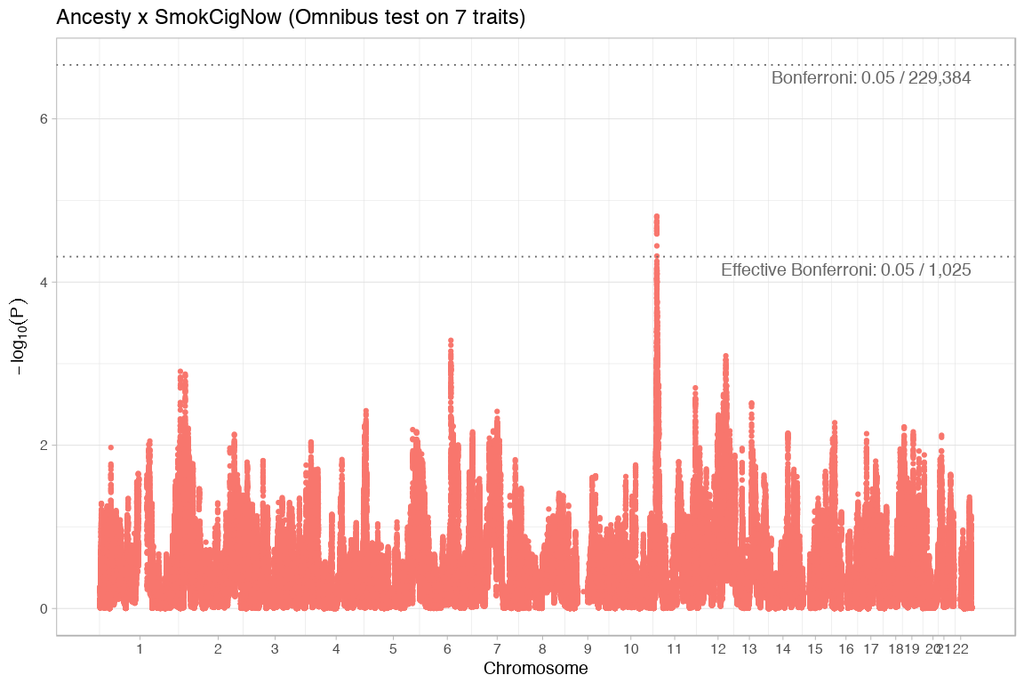

### 3.1.2 Chr 11, PARVA gene

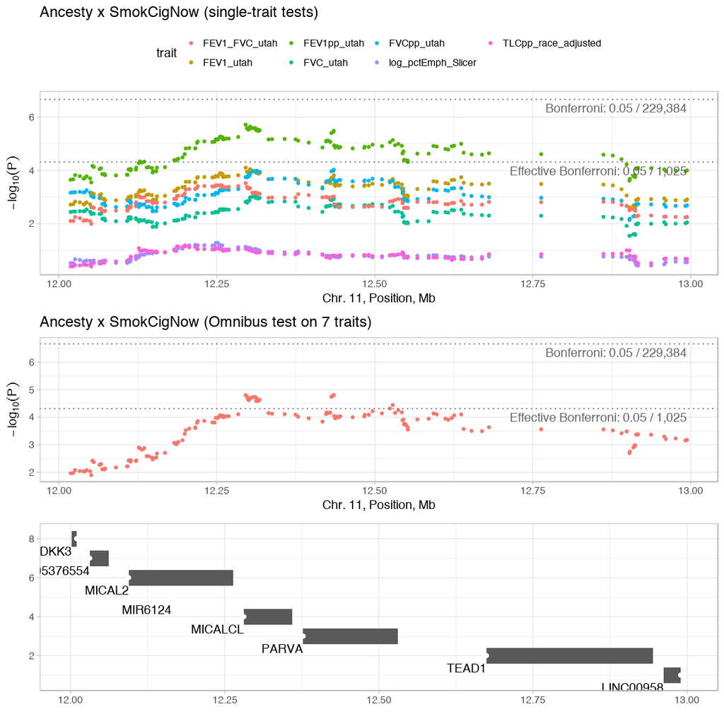

## 3.2 Interaction with SmokCigNow0_15

### 3.2.1 Manhattan plots

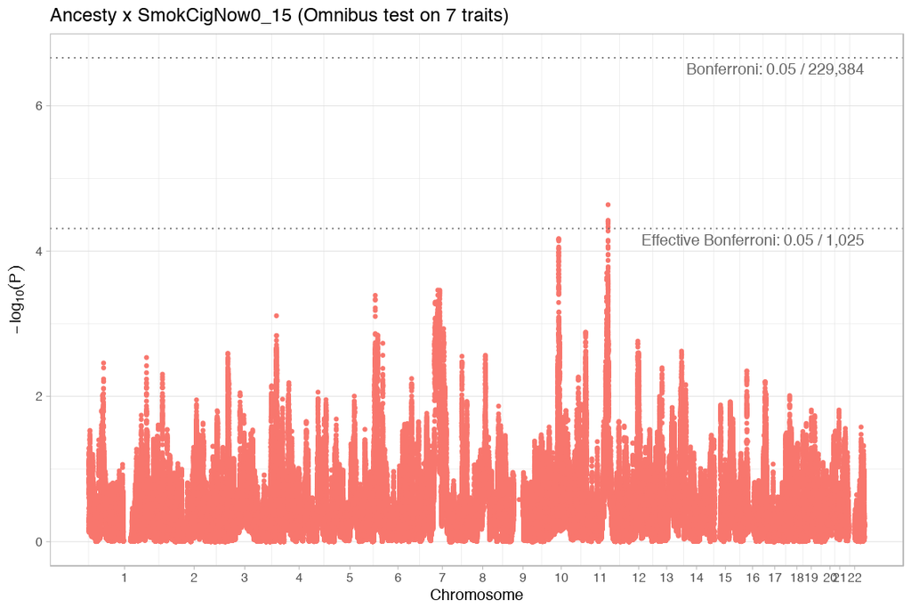

### 3.2.2 Chr 11

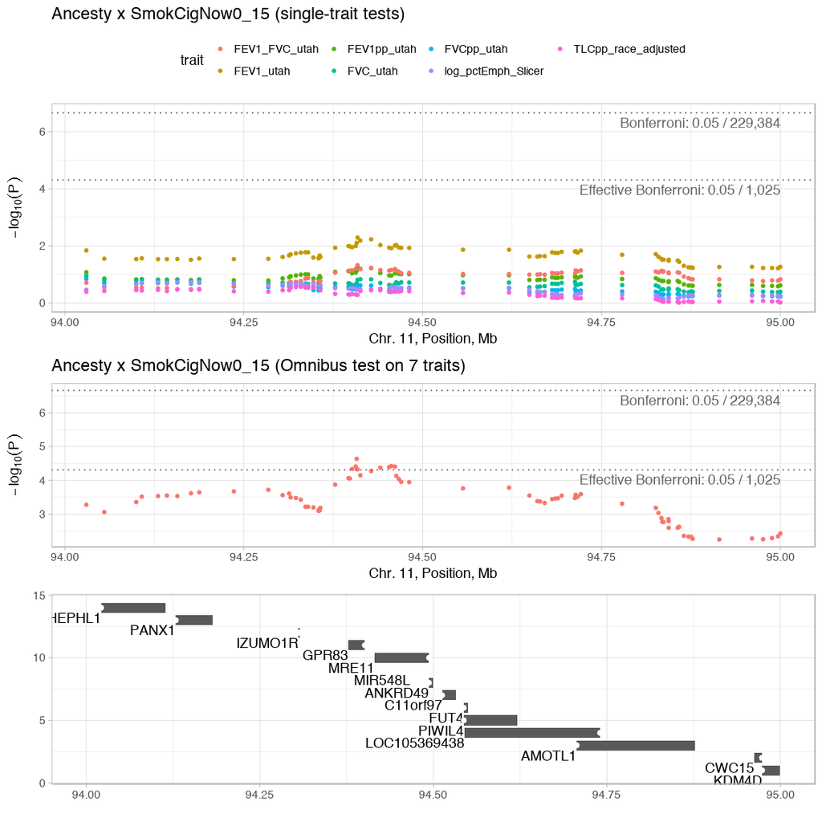

- [ANKRD49](https://www.ncbi.nlm.nih.gov/pubmed/?term=ANKRD49+gene) gene: [A four-gene signature from NCI-60 cell line for survival prediction in non-small cell lung cancer](https://www.ncbi.nlm.nih.gov/pubmed/19920108)
  - Differential analysis in case-control data based on microarray data
- [GPR83](https://www.ncbi.nlm.nih.gov/pubmed/?term=GPR83+gene) gene: [Genetic Associations with Obstructive Sleep Apnea Traits in Hispanic/Latino Americans](https://www.ncbi.nlm.nih.gov/pubmed/26977737)
  - Obstructive sleep apnea (OSA) is the most common type of sleep apnea and is caused by complete or partial obstructions of the upper airway. It is characterized by repetitive episodes of shallow or paused breathing during sleep, despite the effort to breathe, and is usually associated with a reduction in blood oxygen saturation. These episodes of decreased breathing, called “apneas” (literally, “without breath”), typically last 20 to 40 seconds. [wikipedia](https://en.wikipedia.org/wiki/Obstructive_sleep_apnea)

### 3.2.3 Chr 10

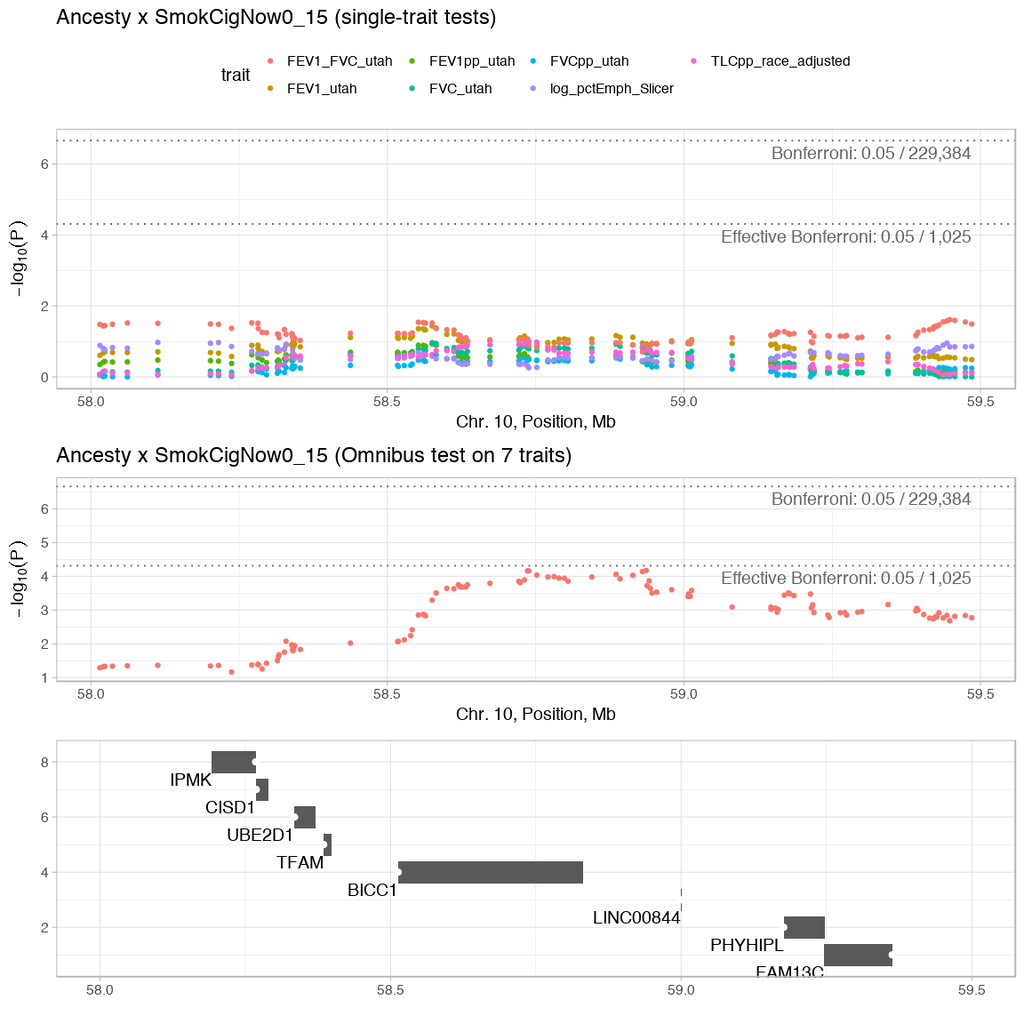

- [BICC1](http://www.genecards.org/cgi-bin/carddisp.pl?gene=BICC1&keywords=bicc1) gene: This gene encodes an RNA-binding protein that is active in regulating gene expression by modulating protein translation during embryonic development. Mouse studies identified the corresponding protein to be under strict control during cell differentiation and to be a maternally provided gene product.

### 3.2.4 Chr 2

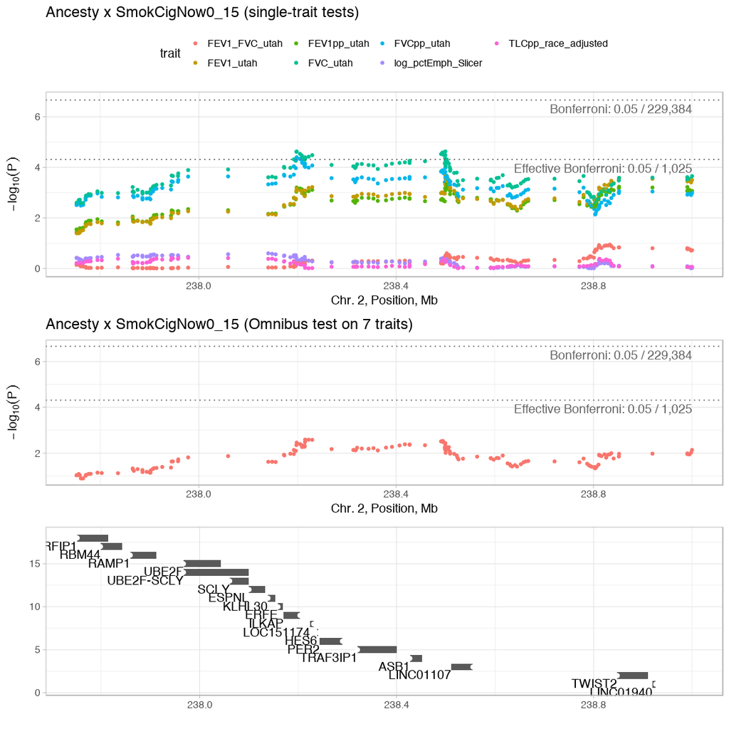

# 4 QQ plots

## 4.1 Interaction with SmokCigNow

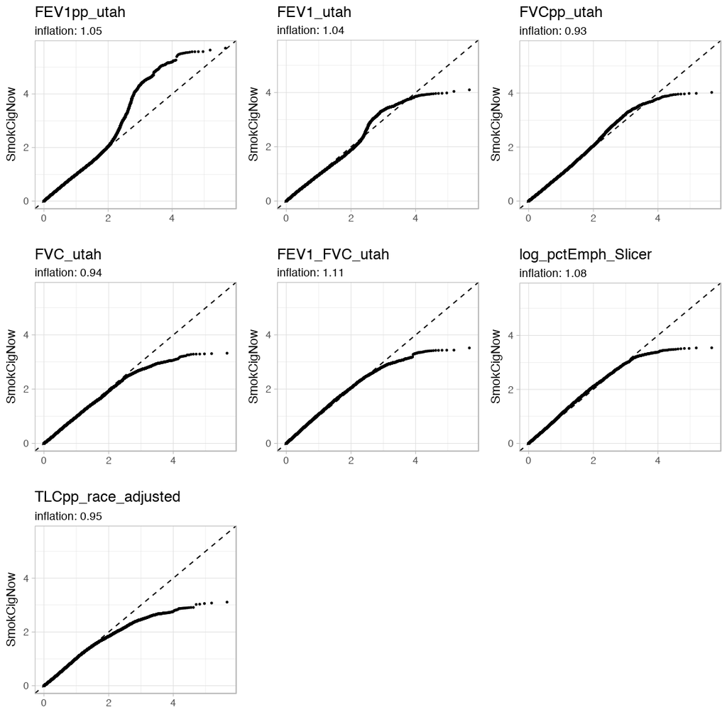

## 4.2 Interaction with SmokCigNow0_15

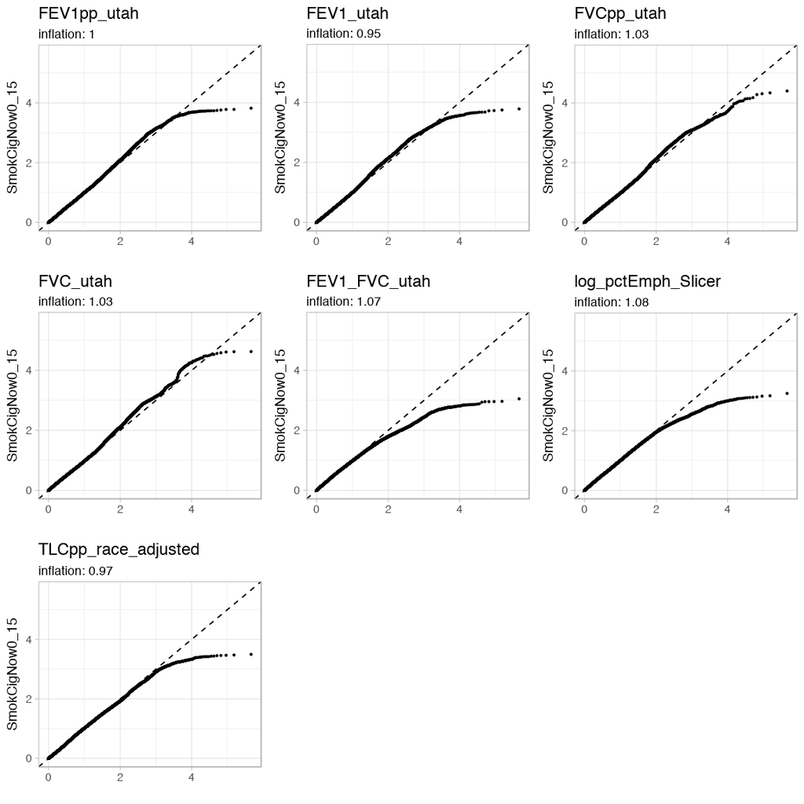

# 5 Quality control on multi-trait analysis

- 7 traits: FEV1pp_utah, FEV1_utah, FVCpp_utah, FVC_utah, FEV1_FVC_utah, log_pctEmph_Slicer, TLCpp_race_adjusted
- threshold: 3

## 5.1 Interaction with SmokCigNow

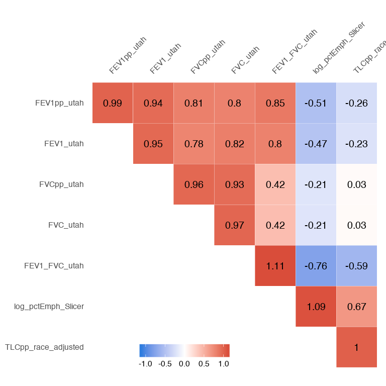

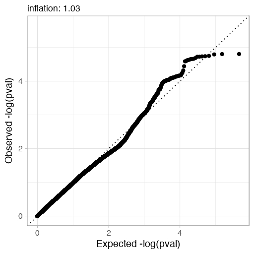

## 5.2 Interaction with SmokCigNow0_15

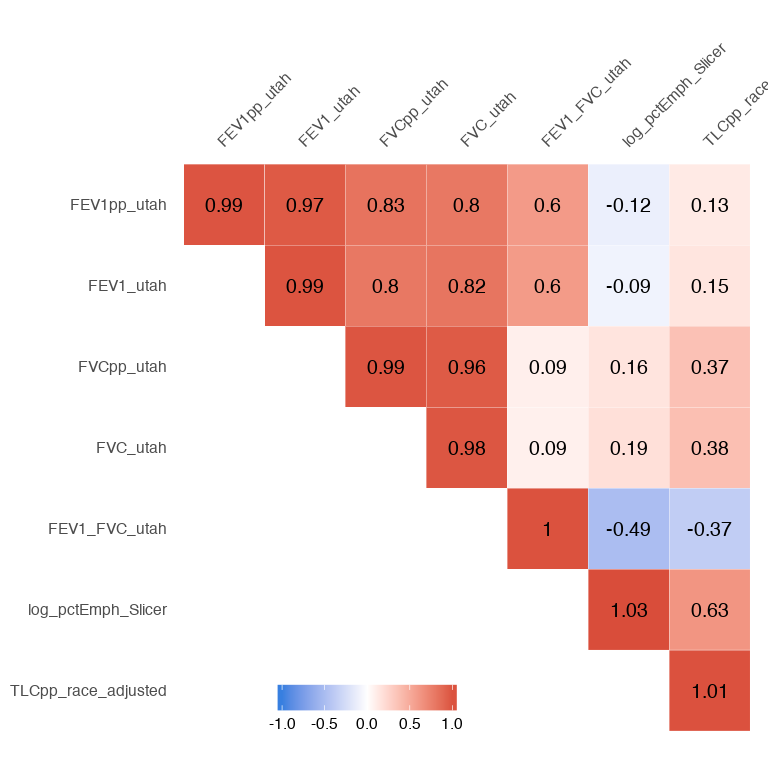

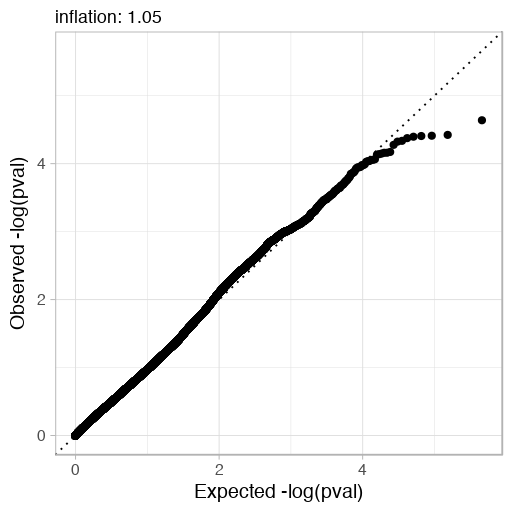

# 6 Models formulas

| trait | ver | formula |
| --- | --- | --- |
| FEV1pp_utah | 9 | imp_FEV1pp_utah ~ Age_Enroll + gender + Duration_Smoking + log_CigPerDaySmokAvg + SmokCigarNow + SmokCigNow + SmokCigNow0_15 + gacs_global2 + (0 + dummy(SmokCigNow0_15Rev)\|rsid1) + (0 + dummy(SmokCig… |
| FEV1_utah | 9 | imp_FEV1_utah ~ Age_Enroll + Age_Enroll2 + gender + Height_CM + Duration_Smoking + log_CigPerDaySmokAvg + SmokCigarNow + SmokCigNow + SmokCigNow0_15 + gacs_global2 + (0 + dummy(SmokCigNow0_15Rev)\|rsi… |
| FVCpp_utah | 9 | imp_FVCpp_utah ~ Age_Enroll + gender + Duration_Smoking + log_CigPerDaySmokAvg + SmokCigarNow + SmokCigNow + SmokCigNow0_15 + gacs_global2 + (0 + dummy(SmokCigNow0_15Rev)\|rsid1) + (0 + dummy(SmokCigN… |
| FVC_utah | 9 | imp_FVC_utah ~ Age_Enroll + Age_Enroll2 + gender + Height_CM + Duration_Smoking + log_CigPerDaySmokAvg + SmokCigarNow + SmokCigNow + SmokCigNow0_15 + gacs_global2 + (0 + dummy(SmokCigNow0_15Rev)\|rsid… |
| FEV1_FVC_utah | 9 | imp_FEV1_FVC_utah ~ Age_Enroll + Age_Enroll2 + gender + Duration_Smoking + log_CigPerDaySmokAvg + SmokCigNow + SmokCigNow0_15 + gacs_global2 + (0 + dummy(SmokCigNow0_15Rev)\|rsid1) + (0 + dummy(SmokCi… |
| log_pctEmph_Slicer | 9 | imp_log_pctEmph_Slicer ~ Age_Enroll + gender + Duration_Smoking + log_CigPerDaySmokAvg + SmokCigarNow + SmokCigNow + SmokCigNow0_15 + gacs_global2 + (0 + dummy(SmokCigNow0_15Rev)\|rsid1) + (0 + dummy(… |
| TLCpp_race_adjusted | 9 | imp_TLCpp_race_adjusted ~ Age_Enroll + gender + Duration_Smoking + log_CigPerDaySmokAvg + SmokCigarNow + SmokCigNow + SmokCigNow0_15 + gacs_global2 + (0 + dummy(SmokCigNow0_15Rev)\|rsid1) + (0 + dummy… |